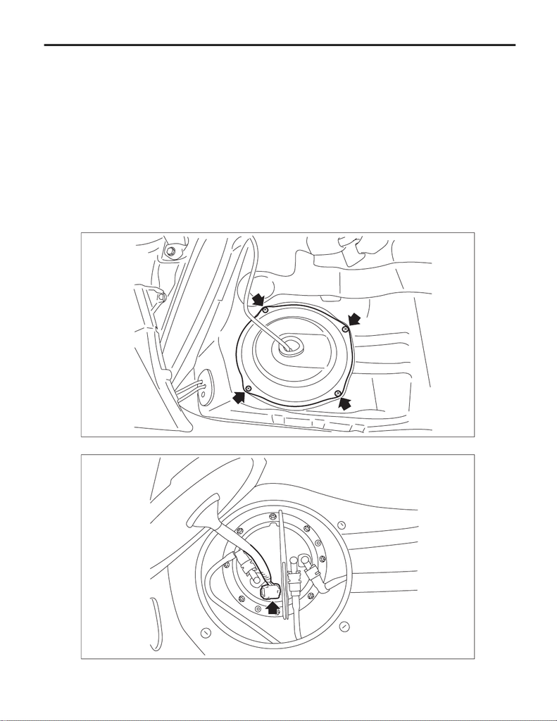

FU(STI)-67

Fuel Tank

FUEL INJECTION (FUEL SYSTEMS)

27.Fuel Tank

A: REMOVAL

WARNING:

Place “NO OPEN FLAMES” signs near the working area.

CAUTION:

• Be careful not to spill fuel.

• Catch the fuel from the tubes using a container or cloth.

1) Release the fuel pressure. <Ref. to FU(STI)-64, RELEASING OF FUEL PRESSURE, PROCEDURE, Fu-

el.>

2) Drain fuel. <Ref. to FU(STI)-64, DRAINING FUEL (WITH SUBARU SELECT MONITOR), PROCEDURE,

Fuel.>

3) Disconnect the ground cable from battery.

4) Remove the rear seat cushion. <Ref. to SE-29, REMOVAL, Rear Seat.>

5) Remove the service hole cover of fuel pump.

6) Disconnect connectors from the fuel pump, and move aside the service hole cover.

FU-06417

FU-08393

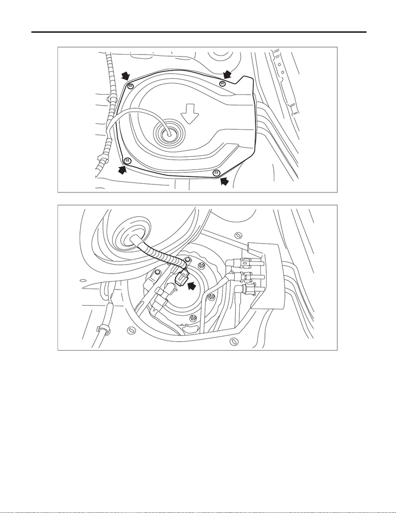

FU(STI)-68

Fuel Tank

FUEL INJECTION (FUEL SYSTEMS)

7) Remove the service hole cover of fuel sub level sensor.

8) Disconnect the connector from the fuel sub level sensor, and move aside the service hole cover.

FU-08394

FU-08395

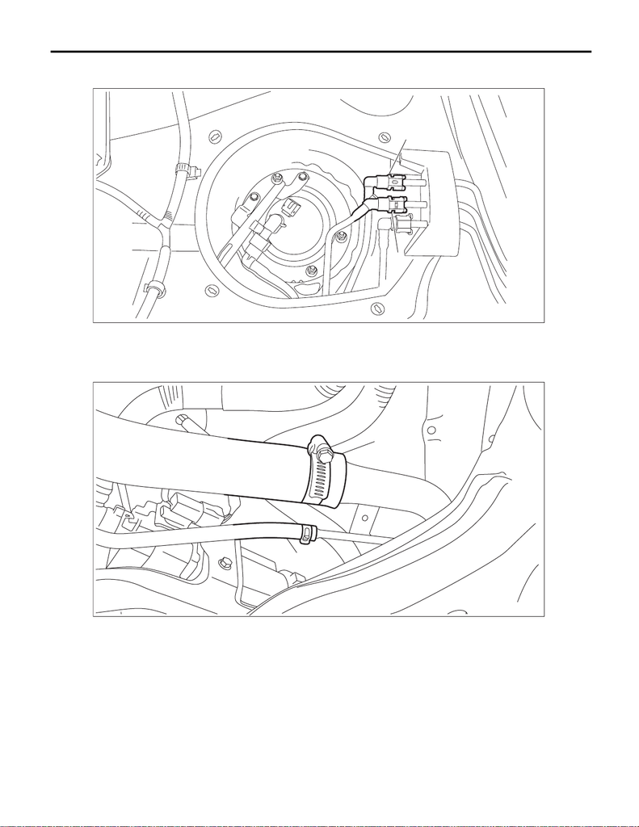

FU(STI)-69

Fuel Tank

FUEL INJECTION (FUEL SYSTEMS)

9) Disconnect the quick connector of fuel delivery tube (A) and fuel return tube (B). <Ref. to FU(STI)-94, RE-

MOVAL, Fuel Delivery, Return and Evaporation Lines.>

10) Lift up the vehicle.

11) Remove the rear exhaust pipe. <Ref. to EX(STI)-12, REMOVAL, Rear Exhaust Pipe.>

12) Remove the rear differential. <Ref. to DI-19, REMOVAL, Rear Differential (T-type).>

13) Disconnect the fuel filler hose (A) and evaporation hose (B) from the fuel filler pipe assembly.

FU-08396

(A)

(B)

FU-08281

(A)

(B)

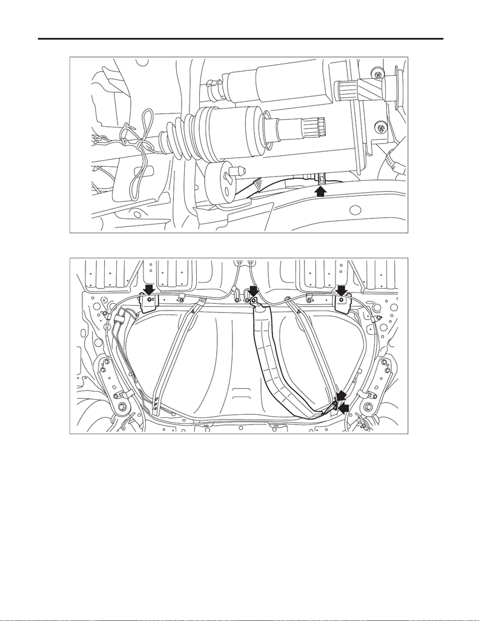

FU(STI)-70

Fuel Tank

FUEL INJECTION (FUEL SYSTEMS)

14) Disconnect the vent tube from vent hose.

15) Remove the fuel tank protector. <Ref. to FU(STI)-66, REMOVAL, Fuel Tank Protector.>

16) Remove the heat shield cover and stopper.

FU-08208

FU-08282

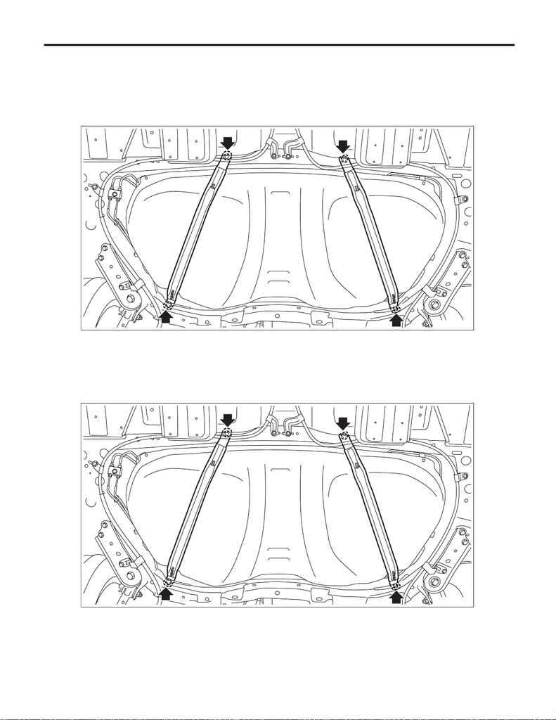

FU(STI)-71

Fuel Tank

FUEL INJECTION (FUEL SYSTEMS)

17) Support the fuel tank with a transmission jack, remove the bolts from the fuel tank band, and remove the

fuel tank from the vehicle.

WARNING:

• A helper is required to perform this work.

• Fuel may remain in the fuel tank. This will cause the left and right sides to be unbalanced. Be care-

ful not to drop the fuel tank.

B: INSTALLATION

1) Support the fuel tank with a transmission jack, set the fuel tank in place, and temporarily tighten the bolts

of the fuel tank band.

WARNING:

A helper is required to perform this work.

FU-08283

FU-08283

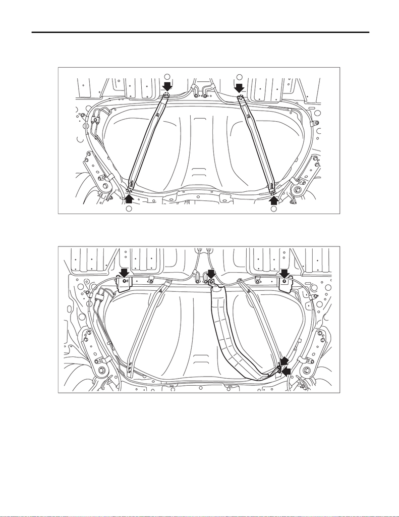

FU(STI)-72

Fuel Tank

FUEL INJECTION (FUEL SYSTEMS)

2) Tighten the bolts of the fuel tank band in the order shown in the figure.

Tightening torque:

33 N·m (3.4 kgf-m, 24.3 ft-lb)

3) Install the heat shield cover and stopper.

Tightening torque:

18 N·m (1.8 kgf-m, 13.3 ft-lb)

4) Install the fuel tank protector. <Ref. to FU(STI)-66, INSTALLATION, Fuel Tank Protector.>

FU-08323

1

2

3

4

FU-08282

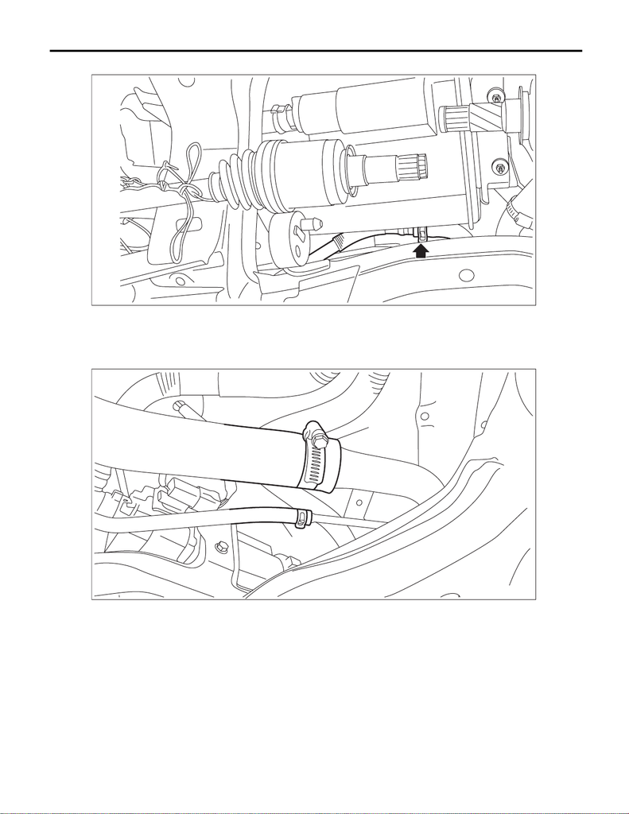

FU(STI)-73

Fuel Tank

FUEL INJECTION (FUEL SYSTEMS)

5) Connect the vent tube to the vent hose.

6) Securely insert the fuel filler hose (A) and evaporation hose (B) until the hose end contacts the spool, then

attach the clamp or clip as shown in the figure.

Tightening torque:

2.5 N·m (0.3 kgf-m, 1.8 ft-lb)

FU-08208

FU-08281

(A)

(B)

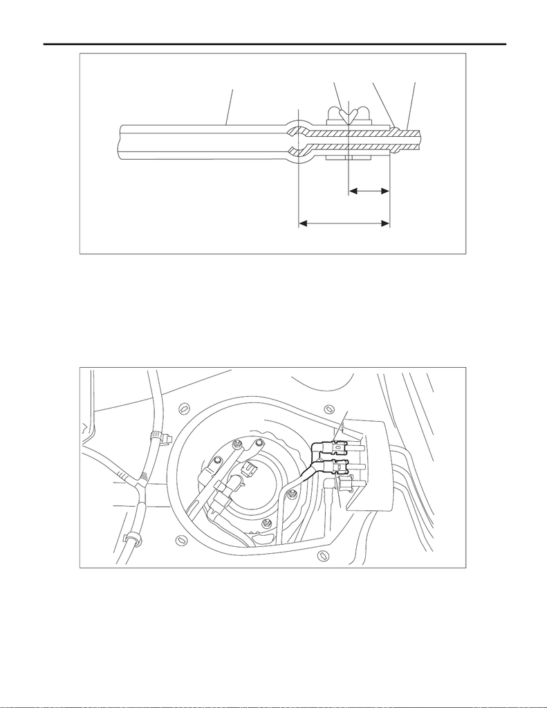

FU(STI)-74

Fuel Tank

FUEL INJECTION (FUEL SYSTEMS)

7) Install the rear differential. <Ref. to DI-21, INSTALLATION, Rear Differential (T-type).>

8) Install the rear exhaust pipe. <Ref. to EX(STI)-12, INSTALLATION, Rear Exhaust Pipe.>

9) Connect the quick connector of fuel delivery tube (A) and fuel return tube (B). <Ref. to FU(STI)-97, IN-

STALLATION, Fuel Delivery, Return and Evaporation Lines.>

NOTE:

When connecting, be careful not to reverse the delivery side and return side.

(1) Hose (3) Spool (4) Pipe

(2) Clamp or clip

L

L/2

(1)

(2)

(3)

(4)

FU-06185

FU-08396

(A)

(B)

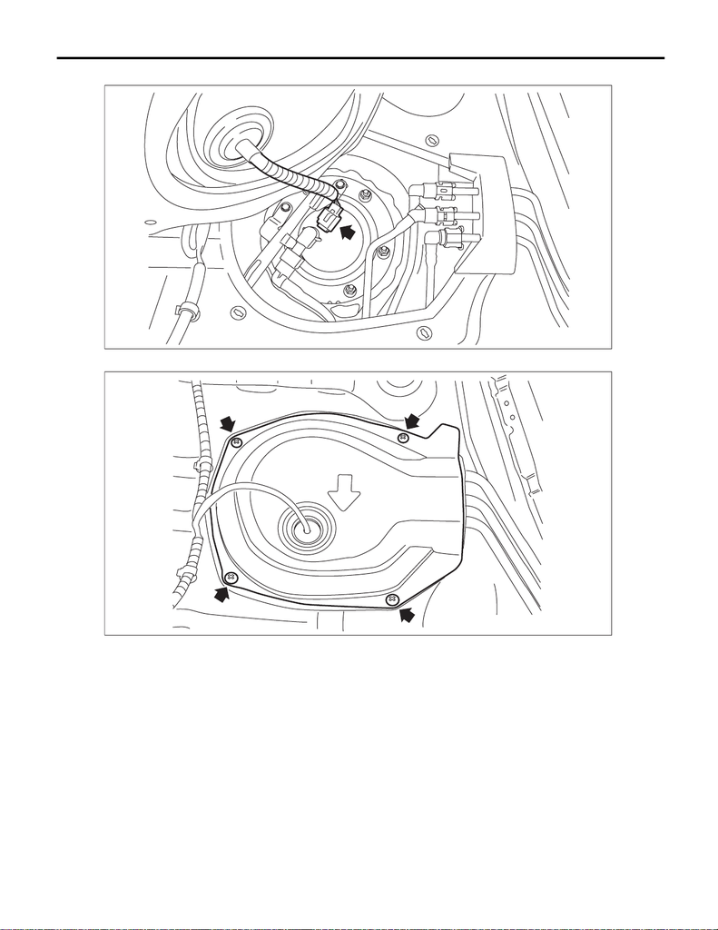

FU(STI)-75

Fuel Tank

FUEL INJECTION (FUEL SYSTEMS)

10) Connect the connector to the fuel sub level sensor.

11) Install the service hole cover of fuel sub level sensor.

FU-08395

FU-08394

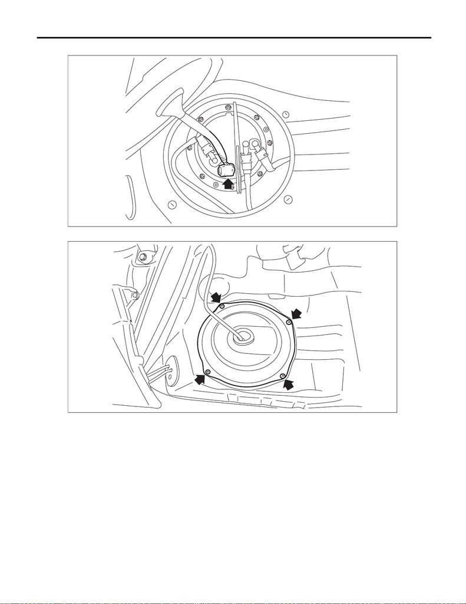

FU(STI)-76

Fuel Tank

FUEL INJECTION (FUEL SYSTEMS)

12) Connect the connector to the fuel pump.

13) Install the service hole cover of fuel pump.

14) Install the rear seat cushion. <Ref. to SE-33, INSTALLATION, Rear Seat.>

15) Connect the battery ground terminal.

C: INSPECTION

1) Check that the fuel tank and fuel pipe have no deformation, cracks and other damages.

2) Check that the fuel hose and tube have no cracks, damage or loose part.

FU-08393

FU-06417